# Exploration

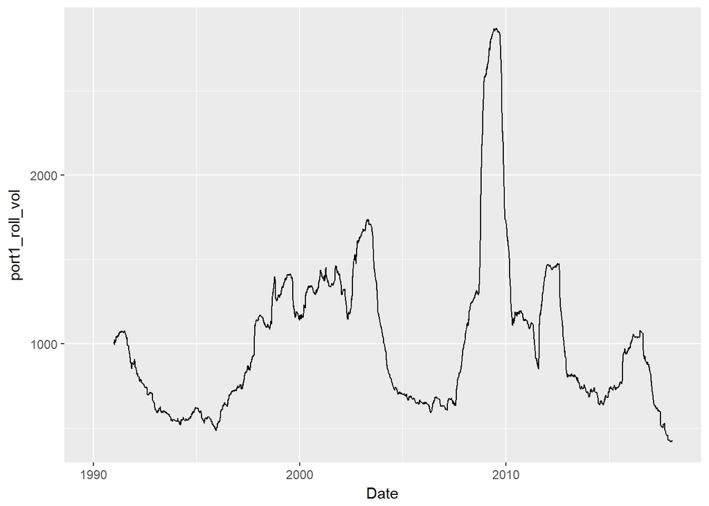

```r
ggplot(t,aes(x=Date)) +
  geom_line(aes(y=port1_roll_vol,na.rm = TRUE))
```

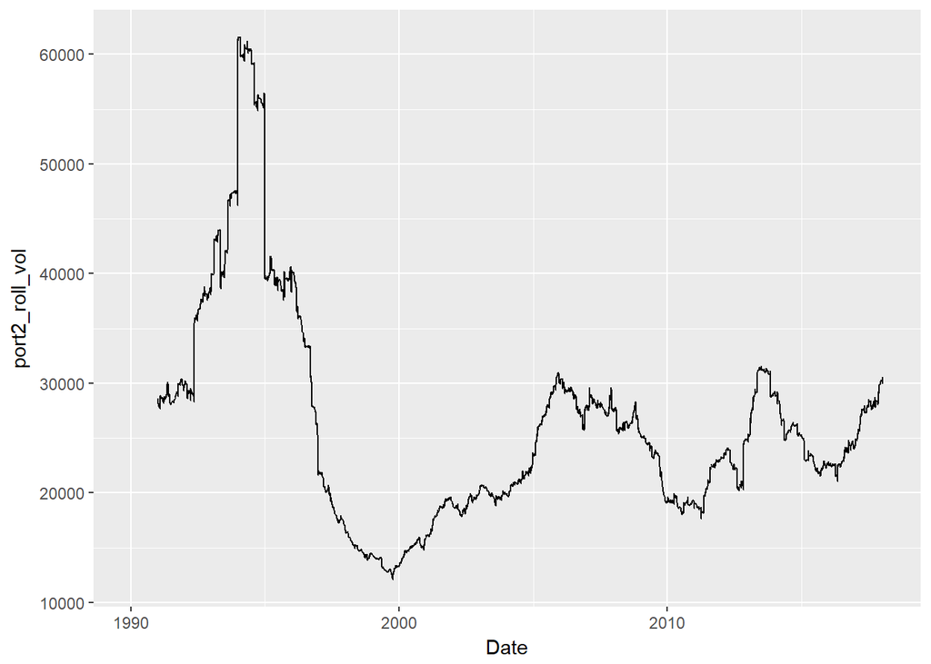

```r
ggplot(t,aes(x=Date)) +
  geom_line(aes(y=port2_roll_vol,na.rm = TRUE))
```

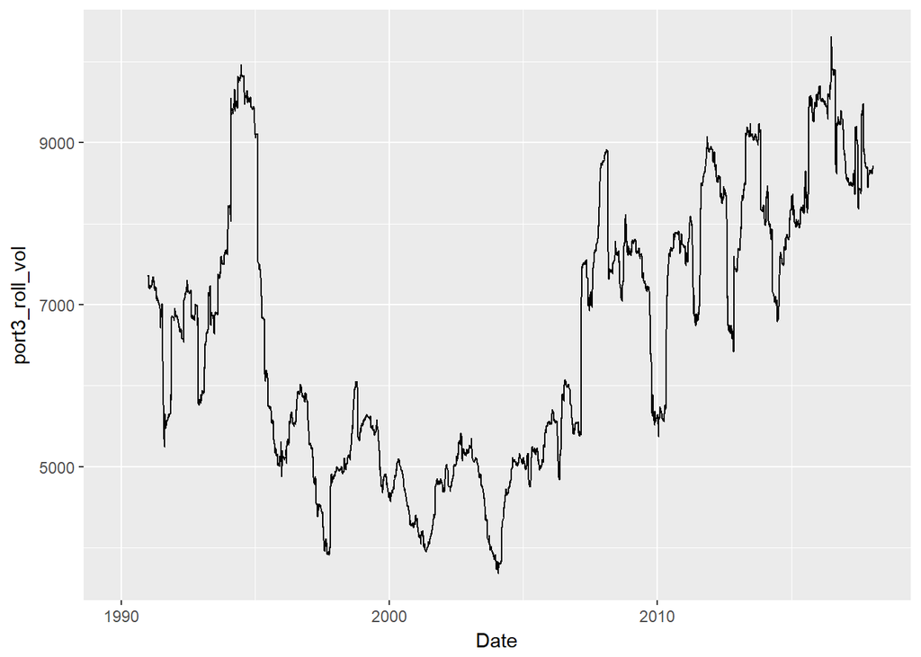

```r
ggplot(t,aes(x=Date)) +
  geom_line(aes(y=port3_roll_vol,na.rm = TRUE))
```

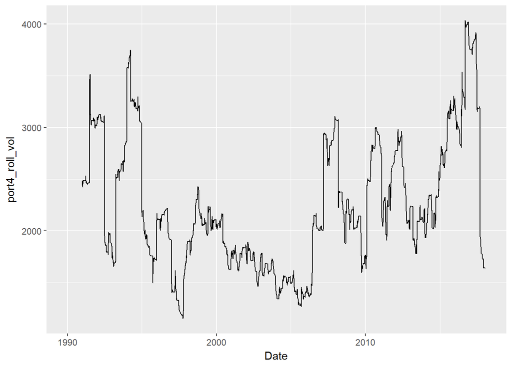

```r
ggplot(t,aes(x=Date)) +
  geom_line(aes(y=port4_roll_vol,na.rm = TRUE))
```

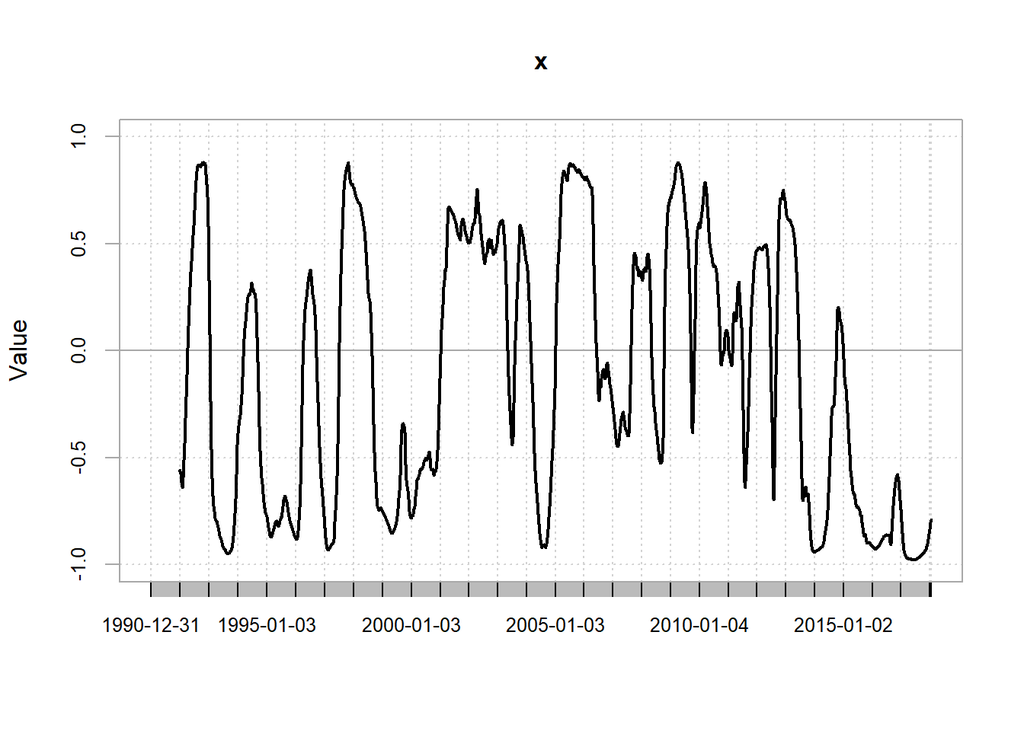

```r
chart.RollingCorrelation(t$port1_roll_mean, t$port1_roll_vol,252)
```

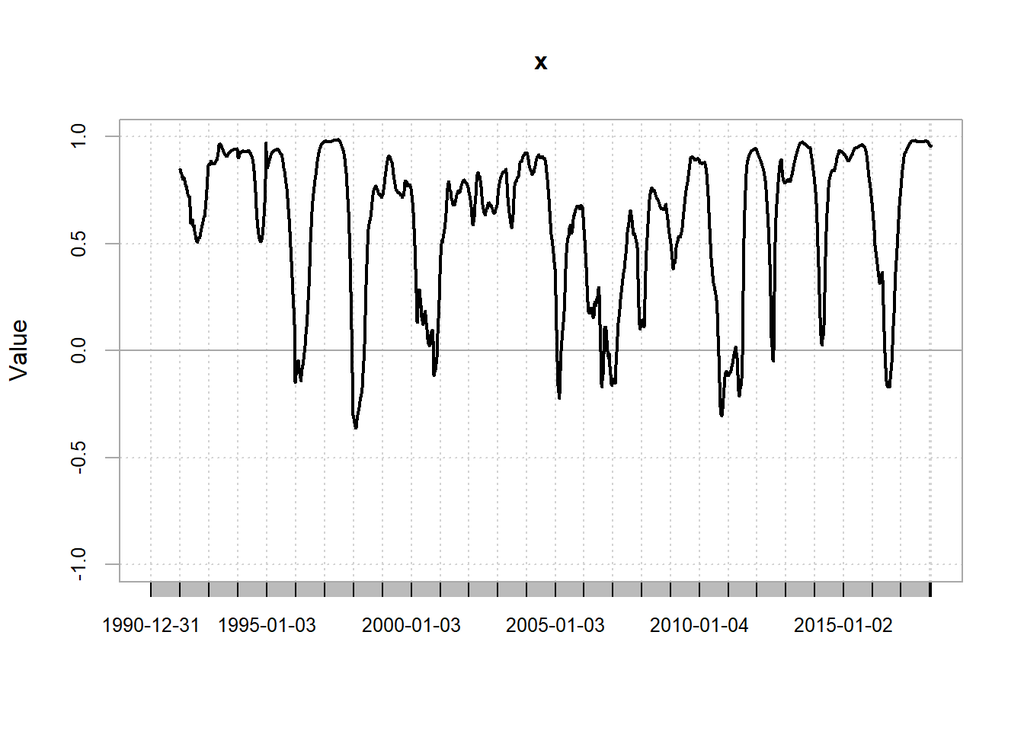

```r
chart.RollingCorrelation(t$port2_roll_mean, t$port2_roll_vol,252)
```

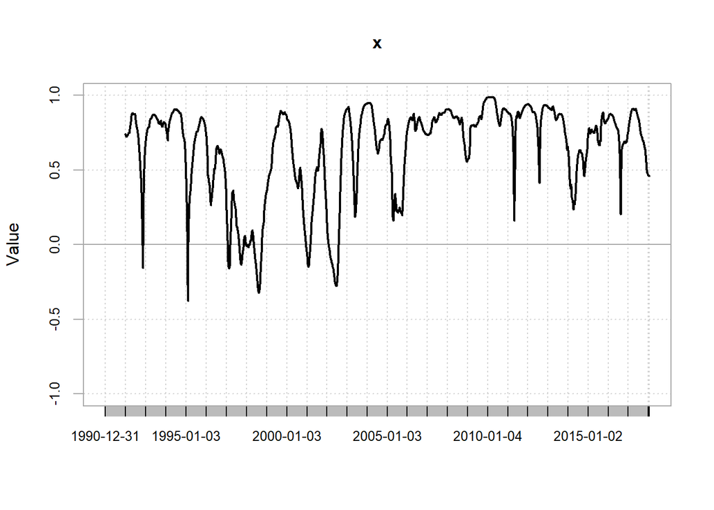

```r
chart.RollingCorrelation(t$port3_roll_mean, t$port3_roll_vol,252)
```

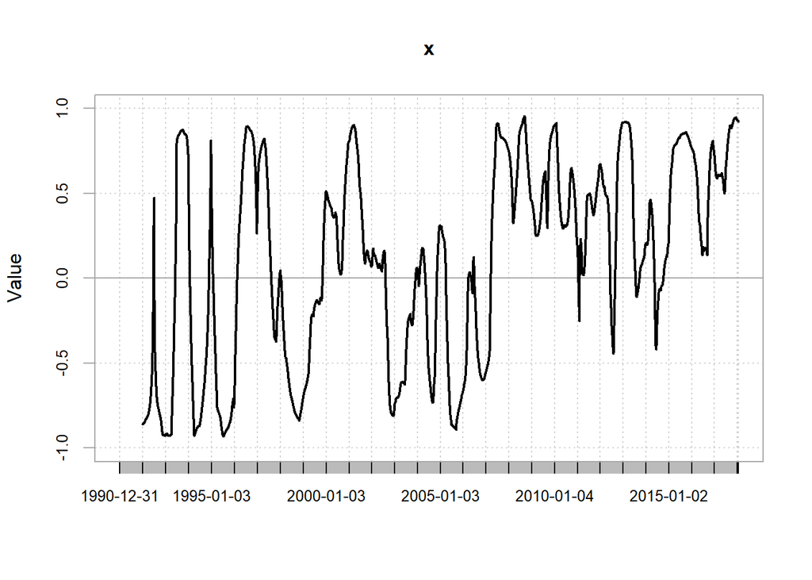

```r
chart.RollingCorrelation(t$port4_roll_mean, t$port4_roll_vol,252)
```

# Rolling Analysis 60 days

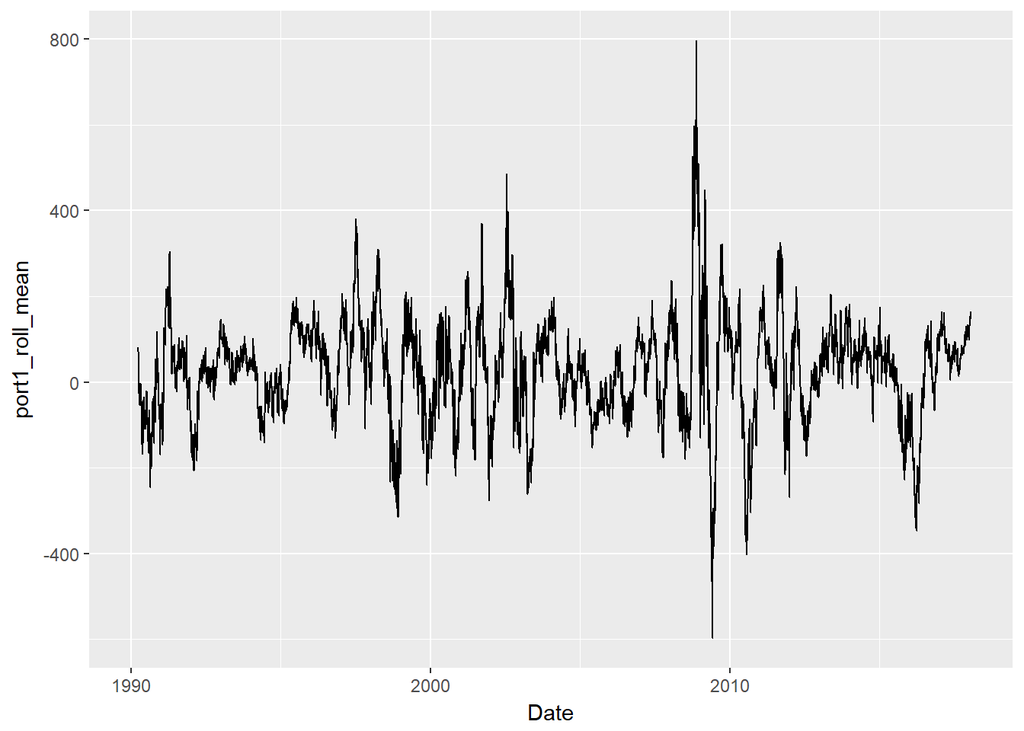

```r
port1 <- xts(x=t$port1_Relreturn, order.by=t$Date)
t$port1_roll_mean <- apply.rolling(port1,60,gap=60,by=1,FUN="mean")
t$port1_roll_vol <- apply.rolling(port1,60,gap=60,by=1,FUN="sd")
port2 <- xts(x=t$port2_Relreturn, order.by=t$Date)
t$port2_roll_mean <- apply.rolling(port2,60,gap=60,by=1,FUN="mean")
t$port2_roll_vol <- apply.rolling(port2,60,gap=60,by=1,FUN="sd")
port3 <- xts(x=t$port3_Relreturn, order.by=t$Date)
t$port3_roll_mean <- apply.rolling(port3,60,gap=60,by=1,FUN="mean")
t$port3_roll_vol <- apply.rolling(port3,60,gap=60,by=1,FUN="sd")
port4 <- xts(x=t$port4_Relreturn, order.by=t$Date)
t$port4_roll_mean <- apply.rolling(port4,60,gap=60,by=1,FUN="mean")
t$port4_roll_vol <- apply.rolling(port4,60,gap=60,by=1,FUN="sd")

ggplot(t,aes(x=Date)) +
  geom_line(aes(y=port1_roll_mean,na.rm = TRUE))
```

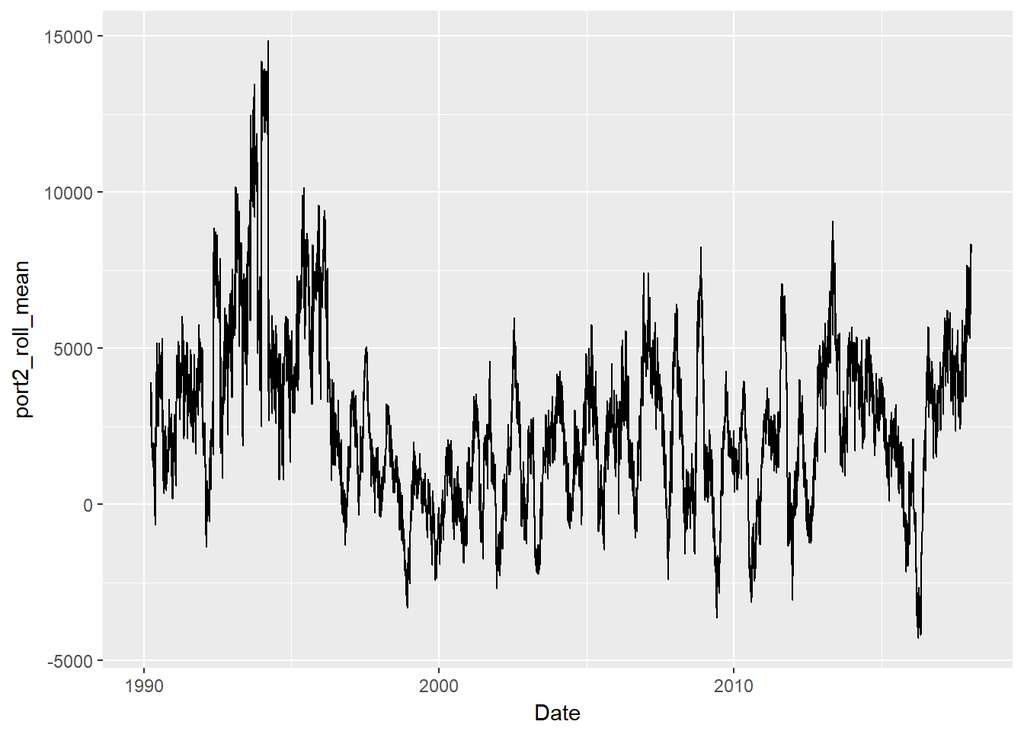

```r
ggplot(t,aes(x=Date)) +
  geom_line(aes(y=port2_roll_mean,na.rm = TRUE))
```

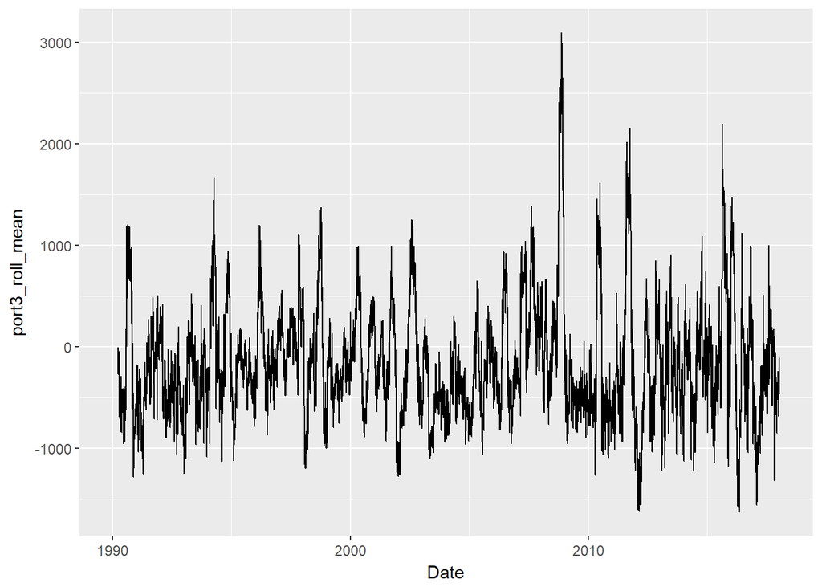

```r
ggplot(t,aes(x=Date)) +
  geom_line(aes(y=port3_roll_mean,na.rm = TRUE))
```

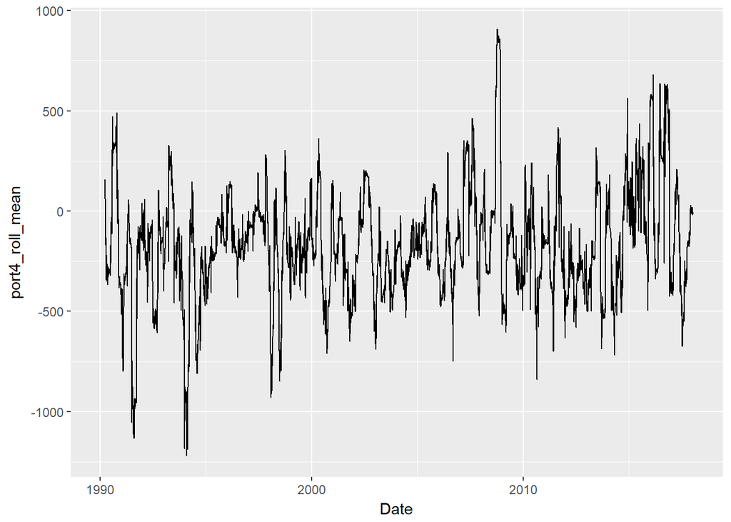

```r
ggplot(t,aes(x=Date)) +
  geom_line(aes(y=port4_roll_mean,na.rm = TRUE))
```

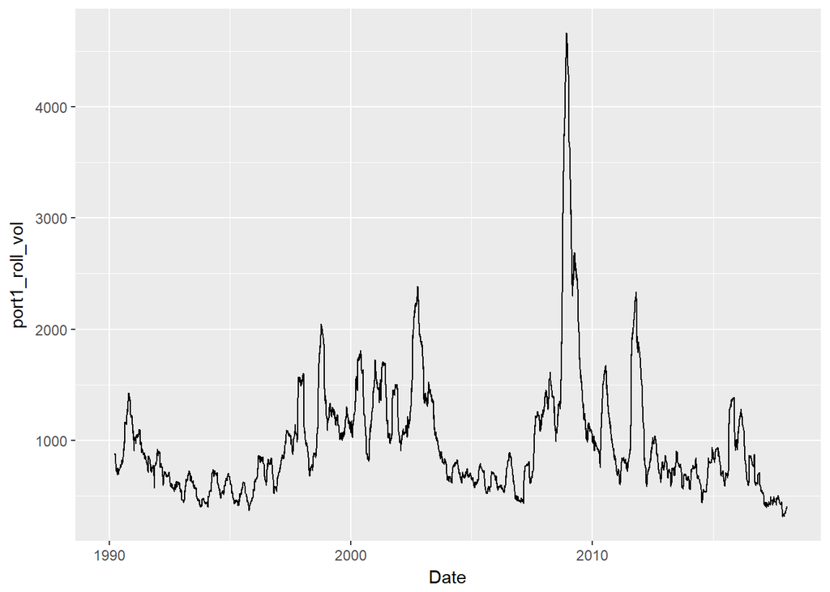

```r
ggplot(t,aes(x=Date)) +
  geom_line(aes(y=port1_roll_vol,na.rm = TRUE))
```

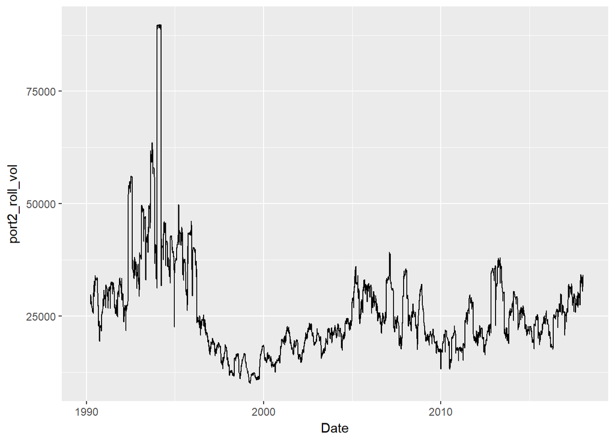

```r
ggplot(t,aes(x=Date)) +
  geom_line(aes(y=port2_roll_vol,na.rm = TRUE))
```

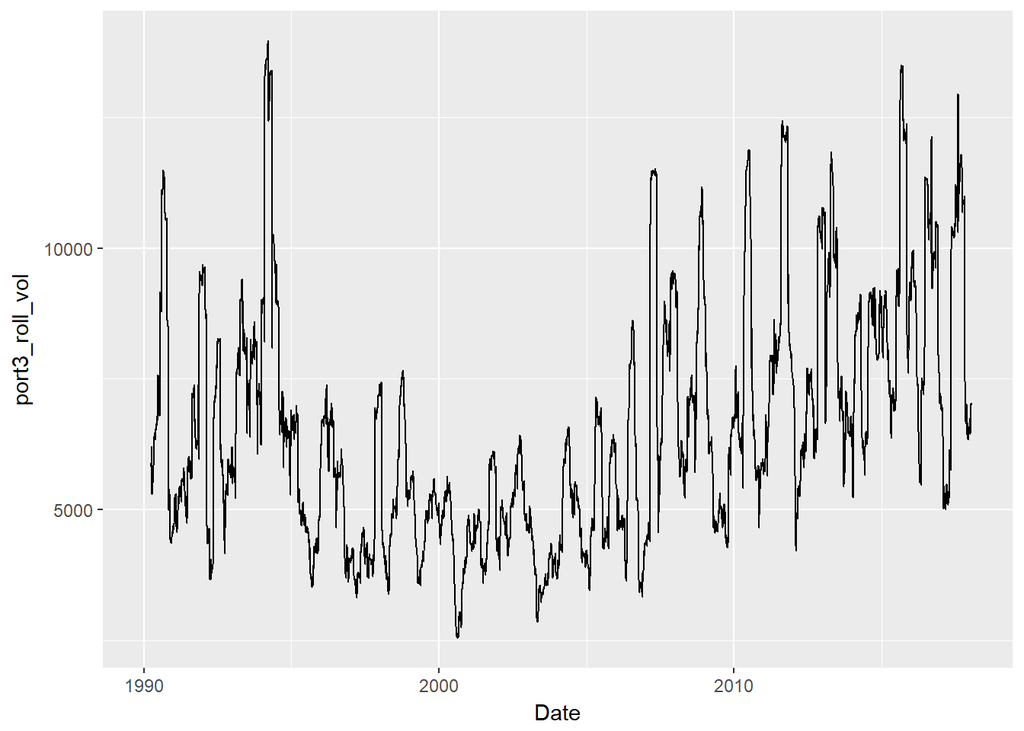

```r
ggplot(t,aes(x=Date)) +
  geom_line(aes(y=port3_roll_vol,na.rm = TRUE))
```

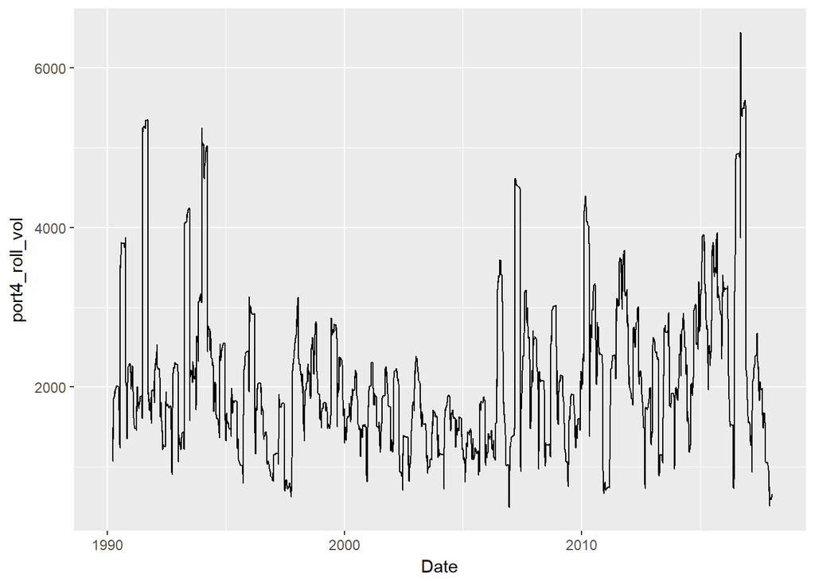

```r
ggplot(t,aes(x=Date)) +
  geom_line(aes(y=port4_roll_vol,na.rm = TRUE))
```

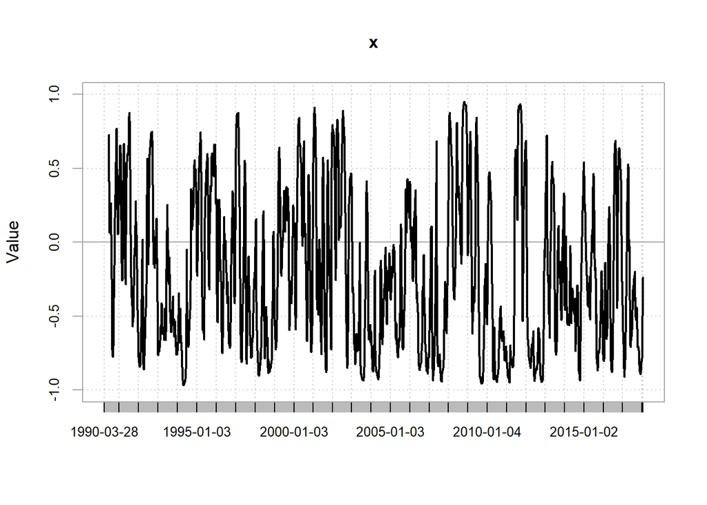

```r
chart.RollingCorrelation(t$port1_roll_mean, t$port1_roll_vol,60)
```

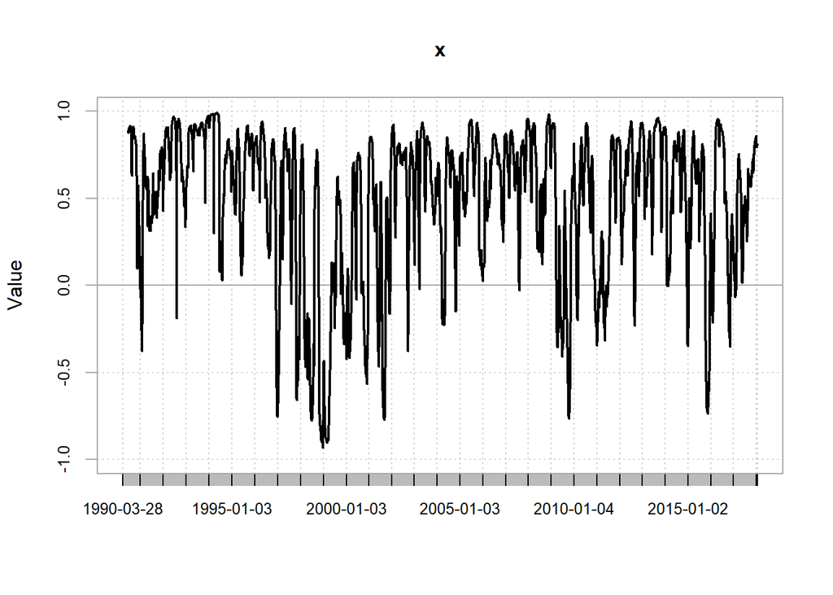

```r
chart.RollingCorrelation(t$port2_roll_mean, t$port2_roll_vol,60)
```

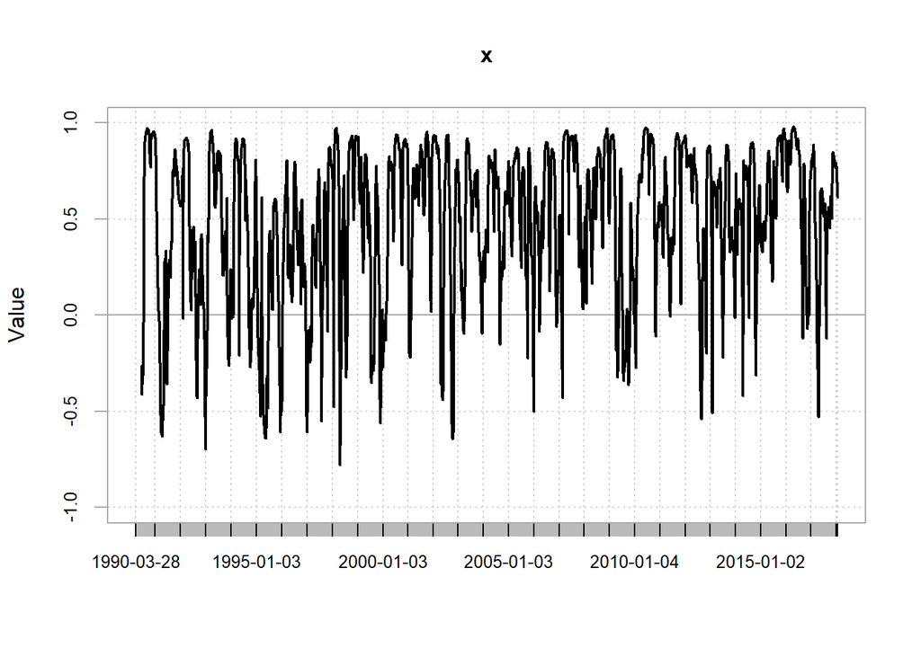

```r
chart.RollingCorrelation(t$port3_roll_mean, t$port3_roll_vol,60)
```

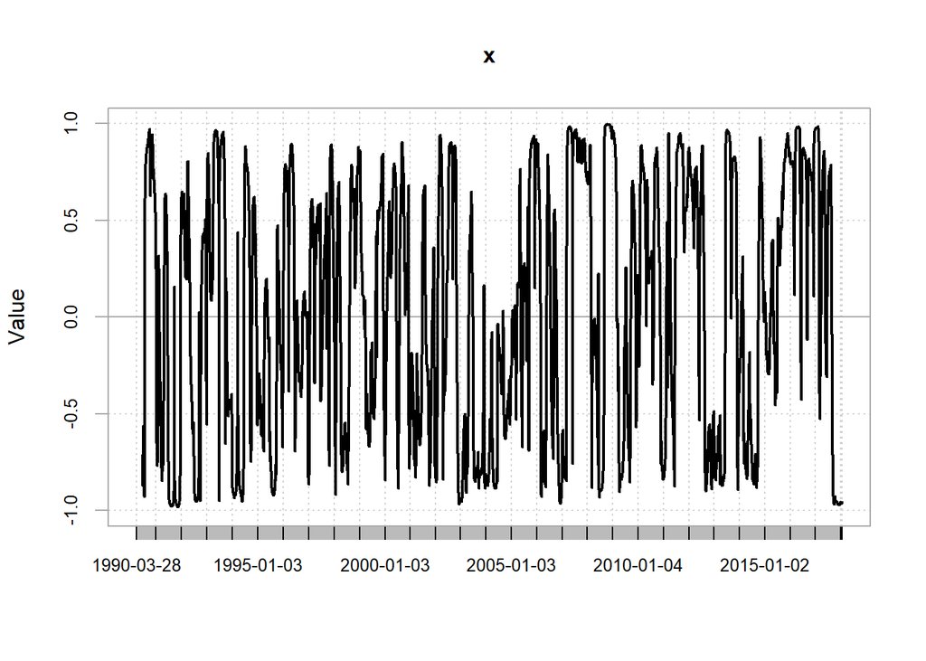

```r
chart.RollingCorrelation(t$port4_roll_mean, t$port4_roll_vol,60)
```

setwd(“F:/Dropbox/[IAQF_Max]/R”) write_csv(t,“../data/data.csv”)

i=1 if (t$signal[i]== 1){ aa <- GBSOption("c",t$Close[i+1],t$Close[i],(90-as.numeric(difftime(t$Date[i+1],t$Date[i])))/365,(t$Free_rate[i+1]/100),0,(t$VIX[i+1]/100)) bb <- GBSOption("c",t$Close[i],t$Close[i],0.246575342,(t$Free_rate[i]/100),0,(t$VIX[i]/100)) } else{ aa <- GBSOption("p",t$Close[i+1],t$Close[i],(90-as.numeric(difftime(t$Date[i+1],t$Date[i])))/365,(t$Free_rate[i+1]/100),0,(t$VIX[i+1]/100)) bb <- GBSOption("p",t$Close[i],t$Close[i],0.246575342,(t$Free_rate[i]/100),0,(t$VIX[i]/100)) }

print(t$Close[i+1]) print(t$Close[i]) t$signal[i] print(aa@price) print(bb@price) print(aa@price-bb@price)

EuropeanOption(“put”, t$Close[i+1], t$Close[i],0, (t$Free_rate[i]/100), (90-as.numeric(difftime(t$Date[i+1],t$Date[i])))/365, (t$VIX[i+1]/100),0, 0)

EuropeanOption(“put”, 110, 100,0, 0.05, 0.24, 0.2,0, 0)